# MATLAB Simulation & Symbolic Algebra Project

Joseph Pym

Table of Contents

Welcome Task One: Collision-less Brownian Motion Tasks a) to c) Task d) and f) Task e) Task Two: Symbolic Algebra Using MATLAB

## Welcome

This project was a first-year coursework I took whilst at university, as part of a module introducing us to MATLAB and LaTeX. The coursework was marked 66% on the two MATLAB tasks, and 33% on the LaTeX write-up. The submitted piece of work (the LaTeX write-up) is [available here](https://jep00.github.io/docs/work/matlabsim.pdf); the GitHub repository is [here](https://github.com/jep00/matlabsim/).

I achieved 90% on the work, and whilst I have learnt a lot of coding techniques and skills since, it is, in my opinion, a good effort for my first major piece of coding.

n.b. As the work was not designed for online viewing, rather just the screenshots of plots were assessed, I'd strongly recommend viewing the final write-up, too, to assess the work.

## Task One: Collision-less Brownian Motion

Task One involved the following tasks:

- a) Plot 'walls' of a container and place up to 500 identical randomly distributed particles within the centre area (radius 100 units). Assign a random value of speed and direction to each particle individually (initial velocity) in a range, such as 10 to 50 units per time interval.
- b) Start your time 'ticking' in discreet intervals (dt) and calculate and plot the updated positions of particles every n time steps. Save every nth screenshot of the plot for your report.
- c) When a particle hits the 'walls' it must be reflected to bounce back without any loss of energy; to demonstrate this, generate a few particles inside and plot the traces of their trajectories as thin solid lines behind. Stop the simulation after some collisions and save the resulting figure.
- d) The code should have the ability to switch on 'gravity': under the action of which, the particles must start to fall down (negative y-direction) and repeatedly bounce against the 'floor'.
- e) Finally, incorporate a 'loss of energy' function (e.g. at each collision, the balls should lose x% of its speed).
- f) On a different plot, show how total energy stays the same in c) and decays in e). What about d)? Comment on your findings.

### Tasks a) to c)

The following code will first initialise our conditions randomly, for the number of particles N, a random angle to 'set off at' θ, a radius within which the points will generate within r, and finally converting θ into polar coordinates, with labels x and y.

```matlab
close all                    % Closes all current figures
% I have named a lot of the variables with
% a after to avoid issues with future code

% Initialisations

figure(1)                    % Opens a new plot

Na   = randi([100 500],1,1); % Generates particles
theta= 360*rand(Na,1,1);     % Random angle between 0 and 360 deg
ra   = 100*rand(Na,1,1);     % Random radius less than 100 units
xa   = ra.*cosd(theta);
ya   = ra.*sind(theta);      % Polar coordinates
```

Each of θ, r, x, and y are vectors length N. We then use the code below to plot the points as 'balls', setting the axis from -500 to 500 in both the x and y directions. We add a title to the plot, too.

```matlab
ha   = plot(xa,ya,'o');      % Plotting the graph
axis manual
axis([-500 500 -500 500])
daspect([1 1 1])
title('Task 1a')             % Plot title
```

Next, we assign each point a random velocity, such that for each point, multiplying this by the horizontal and vertical components of the polar coordinates to find the velocity components.

```matlab
va   = 40*rand(Na,1,1)+10;   % Random veloicty 10 ? v ? 50
vxa  = va.*cosd(theta);      % Horizontal velocity component
vya  = va.*sind(theta);      % Vertical velocity component
```

Reset 'time' and define the 'time-step'. Under time = 250, we update the time and coordinates, plotting the new positions. We save an image of the plot (for use in our LaTeX write-up) at each step of 10.

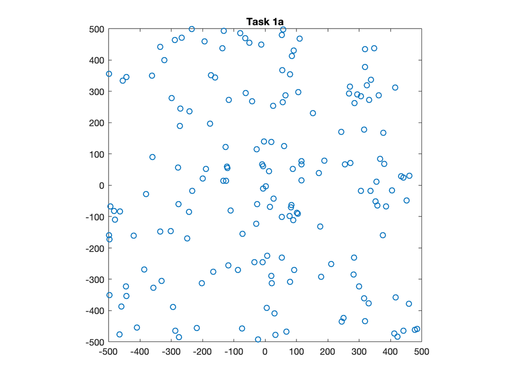

```matlab
ta   = 0;                    % Resets the time
dta  = 2;                    % Time 'step'

while ta<=250
    ta = ta+dta;             % Updates time

    xa = xa+vxa.*dta;        % Updates x coordinate
    ya = ya+vya.*dta;        % Updates y coordinate
    ha.XData = xa;           % Plots the updated x coordinate
    ha.YData = ya;           % Plots the updated y coordinate
    drawnow
    pause(0.005)             % Leaves a 0.05 second gap before continuing

    wallxa = find(abs(xa) >= 500); % Finds any x value outside the bounds
    wallya = find(abs(ya) >= 500); % Finds any y value outside the bounds
    vxa(wallxa) = vxa(wallxa)*-1;  % Flips vxa of x value outside bound
    vya(wallya) = vya(wallya)*-1;  % Flips vya of y value outside bound

    if mod(ta,10)==0 && ta<=250
        filename=['screenshot_taskb_' num2str(ta/10) '.png'];
        saveas(gcf,filename)
    end
end
```

### Task d) and f)

We create a new figure, with the same initialisations as before.

```matlab
figure(3)                    % New figure
Nd   = randi([40 60],1,1);   % Random integer between 40 and 60
theta= 360*rand(Nd,1,1);     % Random angle
rd   = 100*rand(Nd,1,1);     % Random radius
xd   = rd.*cosd(theta);      % Polar coordinate for x
yd   = rd.*sind(theta);      % Polar coordinate for y
hd   = plot(xd,yd,'o');      % Plots x against y
axis manual
axis([-500 500 -500 500])
daspect([1 1 1])
title('task d')              % New Title
vd   = 40*rand(Nd,1,1)+10;   % Random velocity between 10 and 50
vxd  = vd.*cosd(theta);
vyd  = vd.*sind(theta);
td   = 0;                    % Time
dtd  = 1;                    % Time Step
```

```matlab
g    = 9.8;                  % Defines gravity
figure(6)                    % For task f
title('Total Energy, Task d')
en_d  = ones(Nd,1);          % Task f)
toten = plot(td,sum(en_d),'c+:');    % Task f)
hold on                      % Task f)
axis manual                  % Task f)
axis([0 170 0 (Nd+5)])       % Task f)
```

For 150 time points, we again recalculate the components and plot them, as well as finding the total energy in the balls.

[figure not shown]

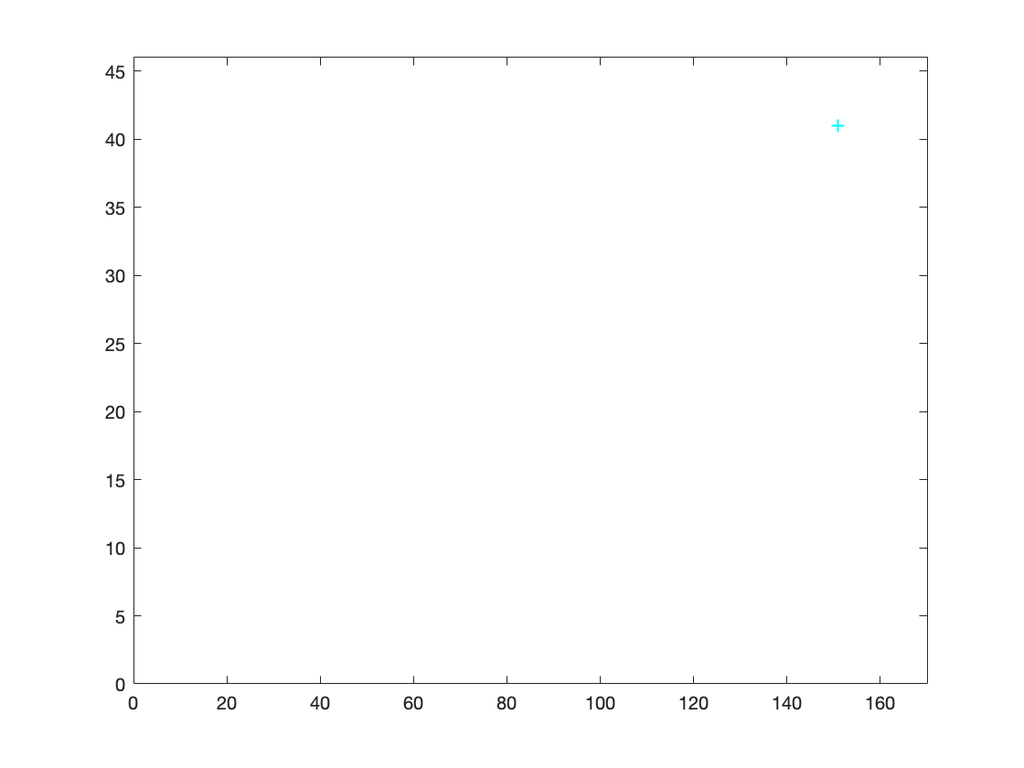

```matlab
while td<=150
    td = td+dtd;             % Time ticks
    vyd=vyd-g*dtd;           % Gravity now has an effect on vertical
                             % component of velocity of particles
    xd = xd+vxd.*dtd;
    yd = yd+vyd.*dtd;
    hd.XData = xd;
    hd.YData = yd;
    drawnow
    pause(0.005)
    wallxd = find(abs(xd) >= 500);  % Finds particles outside walls
    wallyd = find(abs(yd) >= 500);  % Finds particles outside top/bottom
    vxd(wallxd) = vxd(wallxd)*-1;   % Bounces against walls
    vyd(wallyd) = vyd(wallyd)*-1;   % Bounces against bottom/top bounds
    toten.XData = td;           % Task f)
    toten.YData = sum(en_d);    % Task f)
    %sum(en_d)                   % Task f) (Included as a check)
    if mod(td,10)==0 && td<=250 % For 10, 20, 30...240, 250:
        filename=['screenshot_taskd_' num2str(td/10) '.png'];
        saveas(gcf,filename)    % Take a screenshot of the figure
    end
end
```

### Task e)

For the final task, involving the 'loss of energy', we again initialise the conditions.

```matlab
figure(4)                       % New figure
Ne   = randi([30 50],1,1);      % Random number
theta= 360*rand(Ne,1,1);        % Random angle
re   = 100*rand(Ne,1,1);        % Random radius
xe   = re.*cosd(theta);         % Polar x coordinate
ye   = re.*sind(theta);         % Polar y coordinate
he   = plot(xe,ye,'o');         % Plots x against y
axis manual
axis([-500 500 -500 500])
title('Task e')
daspect([1 1 1])
ve   = 40*rand(Ne,1,1)+10;      % Random velocity between 10 and 50
vxe  = ve.*cosd(theta);         % x component of velocity
vye  = ve.*sind(theta);         % y component of velocity
te   = 0;
dte  = 1;
figure(5)                       % New figure for task f)
en   = ones(Ne,1);              % Energy of all particles = 1 (100%)
toten= plot(te,sum(en),'c+:');  % Plots the time against sum of energies
hold on
axis manual
title('Total Energy Task e')
axis([0 170 0 (Ne+5)])          % Size of axis
```

Whilst the time is under 150, we introduce a method to lose 10% of each balls energy upon bouncing against a wall, as well as giving it an effect on the velocity of the ball. The final line, sum(en) was used to ensure the energy is decreasing over time.

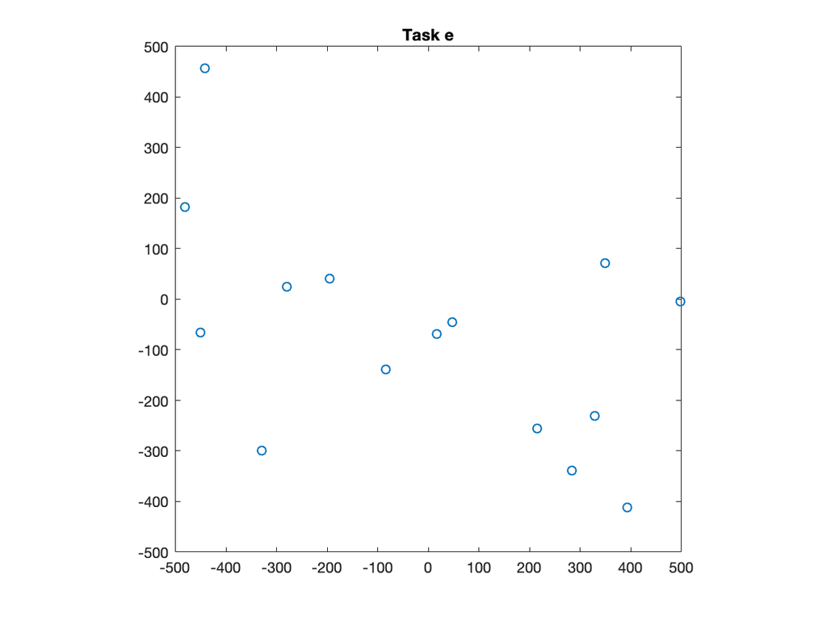

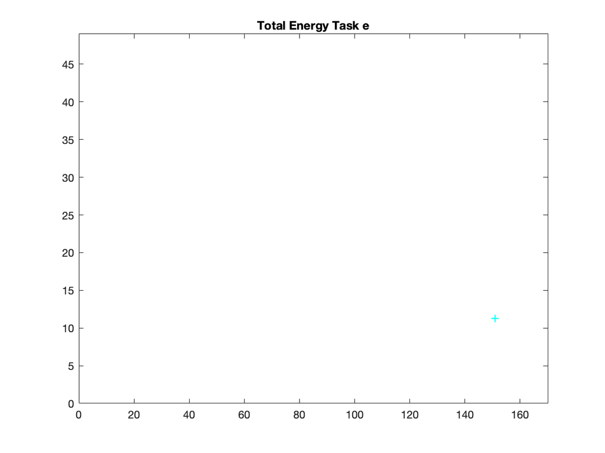

```matlab
while te<=150
    te = te+dte;                % Time tick
    hold on
    xe = xe+vxe.*dte;           % Updates x position
    ye = ye+vye.*dte;           % Updates y position
    he.XData = xe;              % Plots new x coordinate
    he.YData = ye;              % Plots new y coordinate
    toten.XData = te;           % x data of task f) plot is time
    toten.YData = sum(en);      % y data of task f) plot is sum of en
    hold on
    drawnow
    pause(0.01)
    wallxe = find(abs(xe) >= 500);  % Finds particles outside walls
    wallye = find(abs(ye) >= 500);  % Finds particles outside top/bottom
    en(wallxe)  = 0.9 * en(wallxe); % Decreases particle energy by 10%
    en(wallye)  = 0.9 * en(wallye); % Decreases particle energy by 10%
    vxe(wallxe) = vxe(wallxe)*-1.*en(wallxe);  % The energy now has an
    vye(wallye) = vye(wallye)*-1.*en(wallye);  % effect on velocity
    %sum(en)     % Prints the sum of the energy. I used this as a check.
end
```

## Task Two: Symbolic Algebra Using MATLAB

Again, the task was split into subtasks:

'For this task, you use your individual cubic function y(x), found by running the cubic.exe program on Moodle (unique for everyone using student I.D.):'

- a. Find all stationary points of y(x); list their coordinates.
- b. Classify the points using the second derivative test.
- c. Plot y(x) and put small circular markets at the stationary points; put labels to indicate the classification.
- d. Find all the roots of y(x) = 0 and find the value of the integral of y(x) between the roots.

```matlab
syms x
y  = (-3) * x^3 + (12)* x^2 + (-9) * x - 9   % My function, y(x)
```

```matlab
dy = diff(y)                % Differentiates y
```

```matlab
format long                 % Shows to 15 digits
```

```matlab
sp = double(solve(dy,0))    % Finds Stationary Points
```

sp = 2×1

0.451416229645136 2.215250437021530

```matlab
d2 = diff(dy)               % Second Derivative of y
```

```matlab
cl = double(subs(d2,x,sp)); % Stationary Pt -> Second Derivative
mn = find(cl > 0);          % Finds when 2nd Deriv is positive
minimum_points = cl(mn)     % This is a minimum point.
```

minimum_points =

15.874507866387544

```matlab
mx = find(cl < 0);          % Finds when 2nd Deriv is negative
maximum_points = cl(mx)     % This is a maximum point.
```

maximum_points =

-15.874507866387544

Now, we just need to plot the function, and label the stationary points.

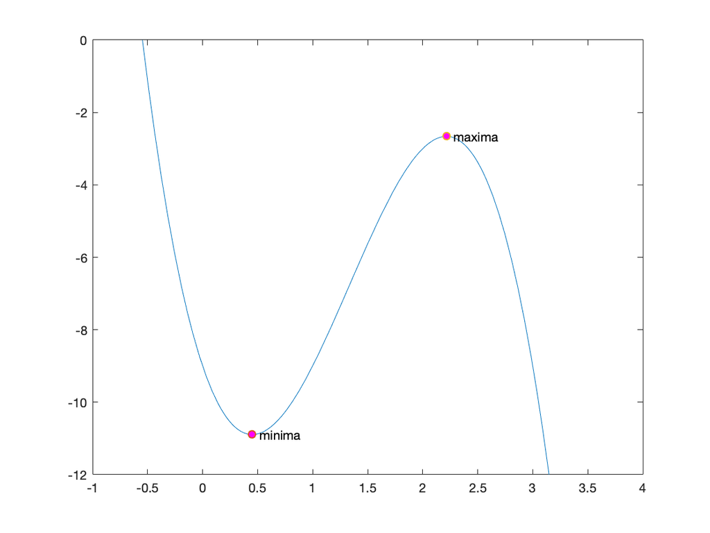

```matlab
figure()                    % Opens an empty figure
fplot(y)                    % Plots y(x)
hold on                     % Holds the current plot
axis manual                 % Freezes any scaling
axis([-1 4 -12 0])          % Sets axis limits
pp1 = subs(y,x,sp(1));      % Finds the y value of the first SP
pp2 = subs(y,x,sp(2));      % Finds the y value of the second SP
plot(sp(1),pp1,'o','MarkerFaceColor','m')
text(sp(1),pp1,'  minima')  % Plots 'minima' at the first SP
plot(sp(2),pp2,'o','MarkerFaceColor','m')
text(sp(2),pp2,'  maxima')  % Plots 'maxima' at the second SP
```

```matlab
% Because I have one real root, I will use the
% first stationary point and the real root
root = double(solve(y==0))  % Finds the roots of y(x)
```

root = 3×1 complex

-0.546818276884082 + 0.000000000000000i 2.273409138442041 - 0.563821092829119i 2.273409138442041 + 0.563821092829119i

```matlab
integral = abs(double(int(y,root(1),sp(1))))
```

integral =

7.497678321655504

```matlab
                            % Finds int of y between the root & first SP.
```